# Dmitrii Zhemchuzhnikov (1)

**Convex and Distributed Optimization Lab**  
**MSIAM — Université Grenoble Alpes — 2018/2019**  
**Lecturers: Jérôme Malick, Yassine Laguel, Sélim Chraibi**

**Author(s): Dmitrii Zhemchuzhnikov**

```python
# Automatic reload of local libraries
%load_ext autoreload
%autoreload 2
%reload_ext autoreload
%matplotlib inline
```

> **I. Introduction**  
> **II. The optimization problem**  
> **III. Implementing the solvers**  
> GD (Gradient descent))  
> SGD (Stochastic Gradient Descent))  
> SAGA (Stochastic Average Gradient "Amélioré"))  
> SVRG (Stochastic Variance Reduced Gradient))  
> Comparison  
> **IV. Regularization**  
> **V. Further development**

In this lab, you will implement optimization algorithms that you've studied in class and use them to fit a logistic regression classification model.

You will be implementing a simplified version of [`sklearn.linear_model.LogisticRegression`](https://scikit-learn.org/stable/modules/generated/sklearn.linear_model.LogisticRegression.html).

Part of the work has already been done for you (see the `\lib` folder), so you'll only have to implement the `##### TODO (i) #####` sections of the code. Whenever you complete such a section, we ask you to **copy it in this notebook**. We want you to **only send us a pdf or html export of this notebook** so we won't be able to see your work if it's not in this notebook.

Report in groups of 1 to 3 students.  
**Due date:** Monday, January 6, 2019 (before midnight).  
**Send to:** cdo.grenoble@gmail.com

# I. Introduction

We consider the [Student Performance](http://archive.ics.uci.edu/ml/datasets/Student+Performance) dataset. This dataset contains student demographic, social, school-related features, how many classes they've missed, etc.

The goal we give ourselves is to predict whether a student will pass (final grade > 12).

We denote $A \in \mathcal{M}_{n,d}(\mathbb{R})$ the feature matrix, containing $n$ samples with $d$ features, and $b \in \{-1,1\}^n$ the label vector where $-1$ encodes `fail` and $1$ encodes `pass`.

The data has already been preprocessed (yay less work for you 🎉). You can check `\lib\datasets.py` if you're curious, otherwise, you can just use the following to load your dataset:

```python
from lib.datasets import load_student_data

A_train, A_test, b_train, b_test = load_student_data('data/student-mat.csv', split=0.25)
```

As mentioned previously, you're going to implement a simplified version of [`sklearn.linear_model.LogisticRegression`](https://scikit-learn.org/stable/modules/generated/sklearn.linear_model.LogisticRegression.html). So let's first see what the finished product should look like.

**Question:**

- Import [sklearn.linear_model.LogisticRegression](https://scikit-learn.org/stable/modules/generated/sklearn.linear_model.LogisticRegression.html) .
- Create an instance of sklearn's logistic regression classifiers with SAGA as its solver.
- Fit the classifier on the training data and compute the score of the fitted model on the test set.

```python
from sklearn.linear_model import LogisticRegression
logreg = LogisticRegression(solver = 'saga', max_iter = 1000)
clf = logreg.fit(A_train, b_train)
```

[output not shown]

# II. The optimization problem

Logistic regression consists in finding the parameter $x \in \mathbb{R}^d$ that best fits: $$ b_i = \begin{cases} \phantom{-}1 \ \textrm{ if }\ \langle a_{i}, x\rangle \ge 0 \\ -1 \ \textrm{ if }\ \langle a_{i}, x\rangle < 0 \end{cases} $$ for all the samples $i$ of the training set (where $a_i$ is the $i^{th}$ line of $A$ and $b_i$ the $i^{th}$ element of $b$). To measure this fit, logistic regression chooses the following loss:

$$ \textrm{LogisticLoss}(b_i, \left\langle a_{i}, x\right\rangle ) = \log \left(1+\exp \left(-b_{i}\left\langle a_{i}, x\right\rangle\right)\right) $$

The corresponding optimization problem we will consider is the following:

Minimization of the empirical risk $f$ of the $L_2$-regularized logistic regression model, on the dataset $(A_{\textrm{train}},b_{\textrm{train}})$: $$ \begin{aligned} \textrm{min}_{x\in \mathbb{R}^d} \ f(x) \ &= \ \textrm{min}_{x\in \mathbb{R}^d} \ \frac{1}{n_{\textrm{train}}} \sum_{i=1}^{n_{\textrm{train}}} f_i(x) \\ &= \ \textrm{min}_{x\in \mathbb{R}^d}\frac{1}{n_{\textrm{train}}} \sum_{i=1}^{n_{\textrm{train}}} \textrm{LogisticLoss}(b_i, \left\langle a_{i}, x\right\rangle ) + \frac{l_2}{2}\|x\|^{2}_2, \end{aligned} $$ where $l_2 \ge 0$ is the $L_2$ regularization coefficient.

To simplify the notation, we'll stop indexing $A$, $b$ and $n$ with "$\textrm{train}$" in the following.

**Question:** $f$ is $\mu$-strongly convex.

- Give a lower bound on $\mu$.
- Complete **TODO (1)** in **\lib\linear_model.py**.

> **Answer:** $g_i(x) = LogisticLoss(b_i, <a_i, x>)$ is a convex function: $$ \alpha g_i(x) + (1 - \alpha) g_i(y) = \alpha \log(1+ \exp( - b_i <a_i, x>)) + (1 - \alpha) \log(1+ \exp( - b_i <a_i, y>)) \geq \log(1+ \exp( - \alpha b_i <a_i, x>)) + \log(1+ \exp( - (1 - \alpha) b_i <a_i, y>)) \geq \log(1+ \exp( - b_i <a_i, \alpha x + (1 - \alpha) y >) = g_i(\alpha x + (1 - \alpha) y) $$ Then $f_i(x) = g_i(x) + \frac{l_2}{2} \|x\|^2_2$ is (at least)$l_2$-strong convex

**Question:** Denote $\lambda_{\max}$ the largest eigenvalue of the real symmetric matrix $AA^T$.

- Prove that $\lambda_{\max}(\nabla^2 f_i) \le \lambda_{\max}(\frac{a_i a_i^T}{4} + l_2 I_d)$
- Prove that $\lambda_{\max}(a_i a_i^T) \le \|a_i\|^2_2$

> **Answer:** $$ \nabla f_i = - b_i a_i \frac{1}{1 + \exp( b_i <a_i, x>)} + l_2 x $$ $$ \nabla^2 f_i = (b_i a_i) (b_i a_i)^T \frac{\exp( b_i <a_i, x>)}{(1 + \exp( b_i <a_i, x>))^2} + l_2 I_d. $$ $\forall x, \|x\| > 0$ $$ \frac{x^T \nabla^2 f_i x}{x^T x} = \frac{(x^T a_i)^2 \frac{\exp( b_i <a_i, x>)}{(1 + \exp( b_i <a_i, x>))^2}}{x^T x} + l_2 \leq \frac{(x^T a_i)^2 \max(h(\exp( b_i <a_i, x>)))}{x^T x} + l_2, $$ where $h(t) = \frac{t}{(1+t)^2}$ has the unique at $1$, $\max_t(h(t)) = h(1) = \frac{1}{4}$ Then, $$ \frac{x^T \nabla^2 f_i x}{x^T x} \leq \frac{(x^T a_i)^2}{4 x^T x} + l_2 $$ Consequently, $$ \max_x \frac{x^T \nabla^2 f_i x}{x^T x} \leq \max_y \frac{(y^T a_i)^2}{4 y^T y} + l_2. $$ And $$ \lambda_{max} (\nabla^2 f_i) \leq \lambda_{max} (\frac{a_i a_i^T}{4} + l_2 I_d) $$ Consider $\lambda_{max} (a_i a_i^T)$: $$ \lambda_{max} (a_i a_i^T) = \max_x \frac{x^T a_i a_i^T x}{x^T x} = \max_x \frac{\|x\|^2 \|a_i\|^2 cos^2 \theta(x)}{\|x\|^2} = \max_{\theta} \|a_i\|^2 cos^2 \theta = \|a_i\|^2, $$ where $\theta$ is angle between $a_i$ and $x$

A consequence of these results is that the $f_i$s and $f$ are all $L$-smooth with $L \ge \frac{\max_i\|a_i\|^2_2}{4} + l_2$ and we can therefore use the following value in our implementation:

```
L = 0.25 * max(np.linalg.norm(A,2,axis=1))**2 + self.l2
```

# III. Implementing the solvers

To implement gradient methods, we need an oracle that will compute both batch gradients $\nabla f$ and partial gradients $\nabla f_i$.

**Question:** In the code below, $\nabla f$ has already been implemented.

- Complete **TODO (2)** bellow.
- Add your code to **\lib\linear_model.py**.

```python
def grad(x, i=None):
    '''
    Gradient of the objective function at x.
    If no i is given, grad should return the batch gradient.
    Otherwise, it should return the partial gradient associated the the datapoint (A[i], b[i]).
    '''

    if i is None: # return batch gradient
        output = -b/(1 + np.exp(b*np.dot(A, x)))
        output = sum(np.diag(output))/n @ A
        output += self.l2*x
    else: # return partial gradient associated the datapoint (A[i], b[i])
        output = -b[i]*A[i]/(1 + np.exp(b[i]*np.dot(A[i], x))) + self.l2*x
    return output
```

# GD (Gradient descent)

At iteration k of the GD algorithm, the following update is executed:

$$ x_{k+1} \leftarrow x_{k} - \gamma\nabla f(x_k) $$

**Question:**

- What stepsize $\gamma$ ensures the convergence of this algorithm and under what assumptions?
- Complete **TODO (3)** and **TODO (4)**
- Add your code to **\lib\solvers.py**.

> **Answer:** The stepsize $0 < \gamma < \frac{2}{L}$ ensures the convergence if the function is bounded from below that happens if $||x_j|| \leq R$, i.e. the set is bounded. We used stepsize $\gamma = \frac{2}{L+\mu}$

```python
def GD(x0, grad, max_iter, n, L, mu):
    '''
    Parameters
    ----------
    x0: array, shape (nb_features,)
        Initialisation of the solver
    grad: function
        Gradient of the objective function
    max_iter: int
        Number of iterations (i.e. number of descent steps). Note that for GD or SVRG,
        one iteration is one epoch i.e, one pass through the data, while for SGD, SAG and SAGA,
        one iteration uses only one data point.
    n: int
        Dataset size
    L: float
        Smoothness constant of the objective function
    mu: float
        Strong convexity constant of the objective function

    Returns
    -------
    x: array, shape (nb_features,)
        final iterate of the solver
    x_tab: array, shape (nb_features, max_iter)
        table of all the iterates
    '''
    stepsize  = 2/(L+mu)
    x         = x0
    x_tab     = np.copy(x)

    for k in range(max_iter):
        f_grad = grad(x_0)
        x     = x - stepsize*f_grad
        x_tab = np.vstack((x_tab, x))

    return x, x_tab
```

**Question:** Run the code below to test your code.

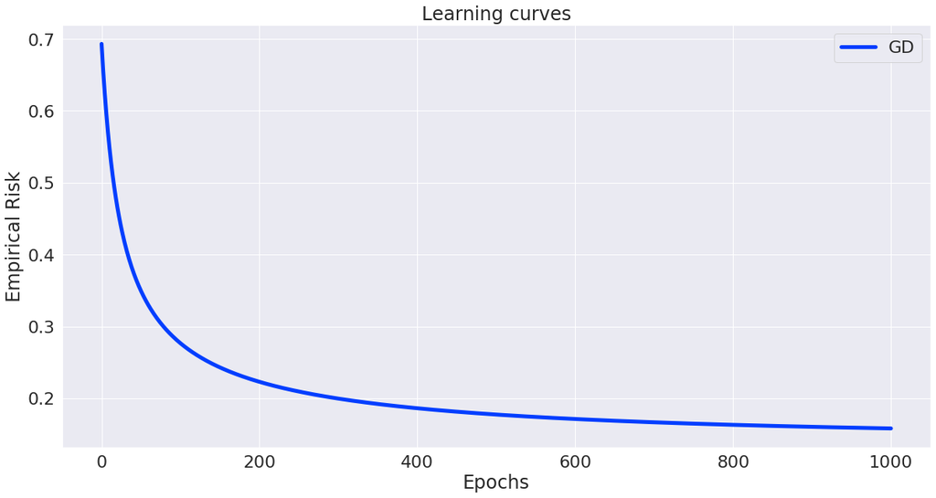

```python
from lib.linear_model import LogisticRegression
from lib.visuals import learning_curve

clf_gd = LogisticRegression(solver='gd', l2=0.01, max_iter=1000)
clf_gd.fit(A_train, b_train)

learning_curve(GD=clf_gd)
```

# SGD (Stochastic Gradient Descent)

At iteration k of the SGD algorithm, the following update is executed:

$$ \begin{cases} i \textrm{ chosen randomly in } \{1...n\}\\ x_{k+1} \leftarrow x_{k} - \gamma_k \nabla f_i(x_k) \\ \end{cases} $$

**Question:**

- What stepsize $\gamma_k$ ensures the convergence of this algorithm and under what assumptions?
- Complete **TODO (5)**
- Add your code to **\lib\solvers.py**.

Stepsize should be less than $\frac{1}{L}$. We chose $\gamma = \frac{2}{L+n\mu}$

```python
def SGD(x0, grad, max_iter, n, L, mu):
    x = x0
    x_tab = np.copy(x)
    i_array = np.random.randint(n, size = max_iter)
    stepsize = 2/(L+n*mu)

    for k in range(max_iter):
        x = x - stepsize*grad(x, i = i_array[k])

        if k%n == 0: # each completed epoch
            x_tab = np.vstack((x_tab, x))

    return x, x_tab
```

**Question:** Run the code below to test your code.

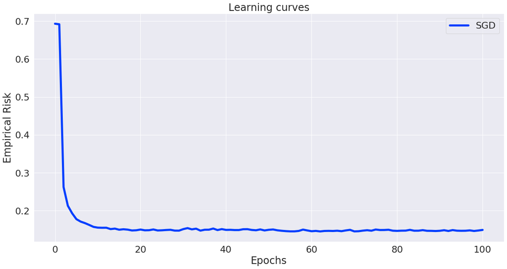

```python
clf_sgd = LogisticRegression(solver='sgd', l2=0.01, max_iter=100*len(b_train))
clf_sgd.fit(A_train, b_train)

learning_curve(SGD=clf_sgd)
```

# SAGA (Stochastic Average Gradient "Amélioré")

SAGA starts by computing a single batch gradient, then at iteration k, the following update is executed:

$$ \begin{cases} i \textrm{ chosen randomly in } \{1...n\}\\ x_{k+1} \leftarrow x_{k} - \gamma_k\big(\nabla f_i(x_k) - \alpha_i + \bar{\alpha}\big) \\ \alpha_i \leftarrow \nabla f_i(x) \end{cases} $$

where $(\alpha_j)_{j=1}^n$ are gradients evaluated at previous iterates and $\bar{\alpha}=\frac{1}{n}\sum^n_{j=1}\alpha_j$.

**Question:**

- What stepsize $\gamma_k$ ensures the convergence of this algorithm and under what assumptions?
- Complete **TODO (6)**
- Add your code to **\lib\solvers.py**.

Stepsize should be less than $\frac{1}{L}$. We chose $\gamma = \frac{1}{3(L+n\mu)}$

```python
def SAGA(x0, grad, max_iter, n, L, mu):
    x = x0
    x_tab = np.copy(x)
    stepsize = 1/(3*(L+mu*n))
    i_array = np.random.randint(n, size = max_iter)
    alpha = 0
    alpha_bar = 0

    for k in range(max_iter):
        f_grad = grad(x, i = i_array[k])
        x = x - stepsize*(f_grad - alpha + alpha_bar)
        alpha = f_grad
        alpha_bar = (k*alpha_bar+alpha)/(k+1)

        if k%n == 0: # each completed epoch
            x_tab = np.vstack((x_tab, x))

    return x, x_tab
```

**Question:** Run the code below to test your code.

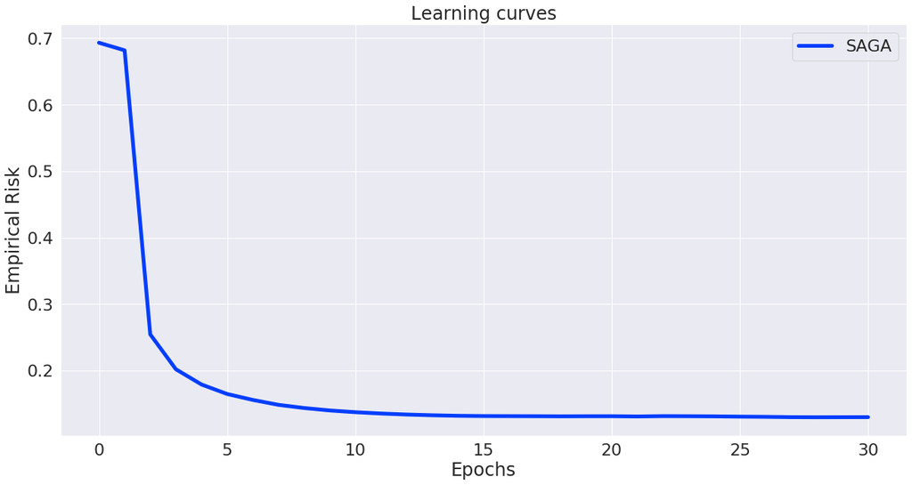

```python
clf_saga = LogisticRegression(solver='saga', l2=0.01, max_iter=30*len(b_train))
clf_saga.fit(A_train, b_train)

learning_curve(SAGA=clf_saga)
```

# SVRG (Stochastic Variance Reduced Gradient)

At iteration k of the SVRG algorithm, we perform the following:

$$ \begin{cases} \textrm{Compute the batch gradient } \nabla f(x_k)\\ \textrm{Initialise }y_0 = x_k\\ \textrm{for m in 0...M-1: } \begin{cases} i \textrm{ chosen randomly in } \{1...n\} \\ y_{m+1} \leftarrow y_{m} - \gamma_k\big(\nabla f_i(y_m) - \nabla f_i(x_k) + \nabla f(x_k)) \end{cases}\\ x_{k+1} \leftarrow y_{M} \end{cases} $$

**Question:**

- What stepsize $\gamma_k$ ensures the convergence of this algorithm and under what assumptions?
- Complete **TODO (7)**
- Add your code to **\lib\solvers.py**.

Stepsize should be less than $\frac{1}{L}$. We chose $\gamma = \frac{2}{3L}$

```python
def SVRG(x0, grad, max_iter, n, L, mu):
    M = 100
    x = x0
    x_tab = np.copy(x)
    stepsize = 2/(3*L)
    for k in range(max_iter):
        f_grad = grad(x)
        y = x
        i_array = np.random.randint(n, size = M)
        for m in range(M):
            y = y - stepsize*(grad(y, i = i_array[m]) - grad(x, i = i_array[m]) + f_grad)
        x =y




        x_tab = np.vstack((x_tab, x))

    return x, x_tab
```

**Question:** Run the code below to test your code.

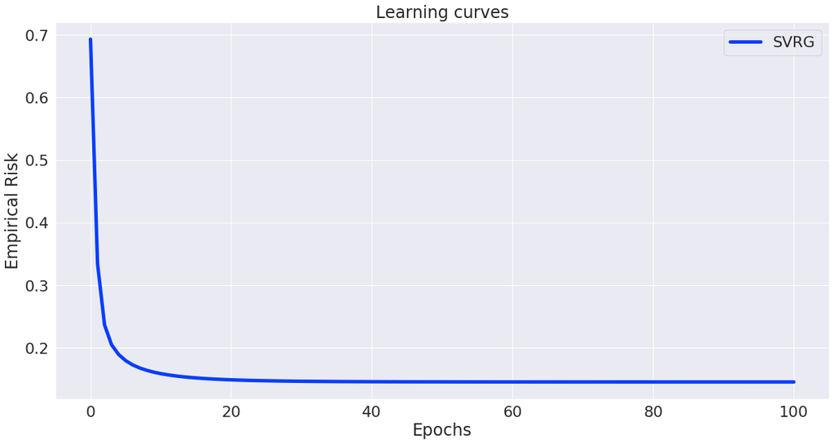

```python
clf_svrg = LogisticRegression(solver='svrg', l2=0.01, max_iter=100)
clf_svrg.fit(A_train, b_train)

learning_curve(SVRG=clf_svrg)
```

# Comparison

**Question:** Run the code below to compare all the methods you've implemented.

```python
epochs = 50
n = len(b_train)

clf_gd   = LogisticRegression(solver='gd', l2=0.01, max_iter=epochs)
clf_sgd  = LogisticRegression(solver='sgd', l2=0.01, max_iter=epochs*n)
clf_saga = LogisticRegression(solver='saga', l2=0.01, max_iter=epochs*n)
clf_svrg = LogisticRegression(solver='svrg', l2=0.01, max_iter=epochs)

clf_gd.fit(A_train, b_train)
clf_sgd.fit(A_train, b_train)
clf_saga.fit(A_train, b_train)
clf_svrg.fit(A_train, b_train)
```

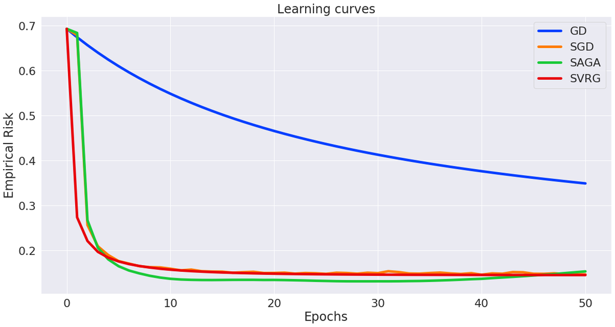

```
gd:	Accuracy on training set: 92.2%
	Accuracy on testing set:  80.8%
sgd:	Accuracy on training set: 97.3%
	Accuracy on testing set:  80.8%
saga:	Accuracy on training set: 96.3%
	Accuracy on testing set:  81.8%
svrg:	Accuracy on training set: 97.0%
	Accuracy on testing set:  80.8%
```

```python
learning_curve(GD=clf_gd, SGD=clf_sgd, SAGA=clf_saga, SVRG=clf_svrg)

for clf, name in zip([clf_gd, clf_sgd, clf_saga, clf_svrg], ['gd', 'sgd', 'saga', 'svrg']):
    print(name + ':' \
          + "\tAccuracy on training set: {0:0.1f}%".format(100*clf.score(A_train, b_train)))
    print("\tAccuracy on testing set:  {0:0.1f}%".format(100*clf.score(A_test, b_test)))
```

# IV. Regularization

**Question:**

- Rewrite the empirical risk minimization objective with both $L_1$ and $L_2$ regularization (with coefficients $l_1$ and $l_2$).
- Is this objective $\mu$-strongly convex, $L$-smooth, differentiable?
- Complete the **TODO (8)** to account for the new term in the objective.
- Add your code to **lib/linear_model.py**.

> **Answer:**

Minimization of the empirical risk $f$ of both $L_1$ and $L_2$-regularized logistic regression model, on the dataset $(A_{\textrm{train}},b_{\textrm{train}})$:

$$ \begin{aligned} \textrm{min}_{x\in \mathbb{R}^d} \ f(x) \ &= \ \textrm{min}_{x\in \mathbb{R}^d} \ \frac{1}{n_{\textrm{train}}} \sum_{i=1}^{n_{\textrm{train}}} f_i(x) = \frac{1}{n_{\textrm{train}}} \sum_{i=1}^{n_{\textrm{train}}} g(x) + l_1 \|x\|_1\\ &= \ \textrm{min}_{x\in \mathbb{R}^d}\frac{1}{n_{\textrm{train}}} \sum_{i=1}^{n_{\textrm{train}}} \textrm{LogisticLoss}(b_i, \left\langle a_{i}, x\right\rangle ) + l_1 \|x\|_1 + \frac{l_2}{2}\|x\|^{2}_2, \end{aligned} $$

where $l_1 \ge 0 $ and $l_2 \ge 0$ is $L_1$ and $L_2$ regularization coefficients.

If functions $h_i(x) = LogisticLoss(b_i, <a_i, x>)$ are convex then $s(x) = \sum_i h_i(x) + l_1\|x\|_1$ is a convex function as the sum of convex terms. And $f(x) = s(x) + \frac{l_2}{2}\|x\|_2^2$ is $l_2$-strongly convex by definition.

Consider $\nabla^2 g(x) \le L$ where $g(x) = \sum h_i(x) + \frac{l_2}{2}\|x\|_2^2$. Consequently, $\nabla^2 f(x) = \nabla^2 g(x) + \nabla^2 l_1 \|x\|_1 = \nabla^2 g(x) + 0 \le L$ and $f(x)$ is $L$-smooth.

```
self._empirical_risk = lambda x: sum(self._logistic_loss(A, b, x))/n \
                                 + self.l2/2.0 * np.linalg.norm(x,2) \
                                 + self.l1 * np.linalg.norm(x,1)
```

The minimization algorithms we've implemented have a slow rate of convergence for this new objective function. We will therefore use *proximal* variations of these algorithms.

**Question:** Using the $\textrm{prox}_{l_1 \|\cdot\|_1}$ operator, write down the $k^{th}$ step of proximal GD, proximal SGD, proximal SAGA, and proximal SVRG.

> **Answer:** $$ x_{k+1} = \text{prox}_{l_1\|.\|_1}(x_k - \gamma \nabla g_k(x)) $$

**Question:**

- Give a closed-form expression of $\textrm{prox}_{l_1 \|\cdot\|_1}$
- Complete **TODO (9)** (note that you can access the $l_1$ coefficient using **self.l1**).
- Add your code to **\lib\linear_model.py**.

> **Answer:** $$ \text{prox}_{l_1\|.\|_1}(t)_i = \text{sign}(t_i) \max(0, |t_i| - l_1) $$

```python
def prox(x, l1):
    output = np.ones_like(x)
    output[x > l1] = x[x > l1] - l1
    output[x <-l1] = x[x <-l1] + l1
    return output
```

**Question:**

- Add **prox** to the attributes of the solvers (both in the call to **self.solver** in **/lib/linear_model.py** and in **/lib/solvers.py**) as follows:  
  solver(x0, grad, **prox**, self.max_iter, n, L, mu)
- Add a proximal step to all the algorithms in **/lib/solvers.py**.
- Paste one of these algorithms in the cell bellow.

```python
def SGD(x0, grad, max_iter, n, L, mu, prox=None, l1=None):
    x = x0
    x_tab = np.copy(x)
    i_array = np.random.randint(n, size = max_iter)
    stepsize = 1/(2*(L+mu*n))

    for k in range(max_iter):
        if prox == None:
            x = x - stepsize*grad(x, i = i_array[k])
        else:
            x = prox(x - stepsize*grad(x, i = i_array[k]),l1)

        if k%n == 0: # each completed epoch
            x_tab = np.vstack((x_tab, x))

    return x, x_tab
```

**Question:** If your proximal gradient descent is correctly implemented, the following cell will plot the support of the solution for various values of $l_1$.

- Interpret the plot and explain what can $L_1$ regularization be used for.

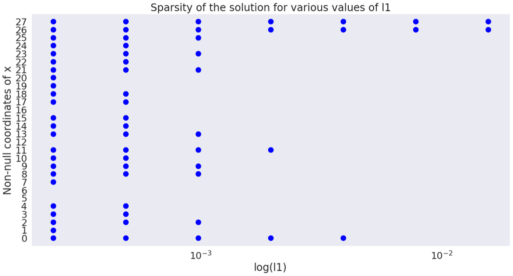

```python
from lib.visuals import l1_regularization_plot

clf = lambda l1: LogisticRegression(solver='svrg', l1=l1, l2=0.1, max_iter=1000, l1_reg = True)

l1_regularization_plot(clf, A_train, b_train)
```

**Question:** The following cell will plot the value of the coordinates of the solution for various values of $l_2$.

- Interpret the plot and explain what can $L_2$ regularization be used for.

> **Answer:** $L_2$-regularization forces the weights to be small but does not make them zero and does non sparse solution.

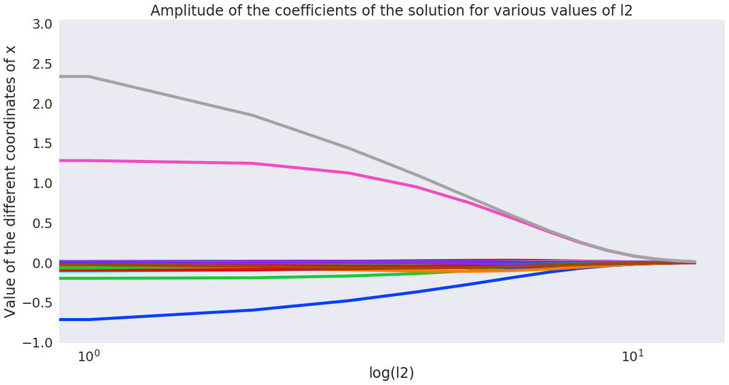

```python
from lib.visuals import l2_regularization_plot

clf = lambda l2: LogisticRegression(solver='svrg', l1=0.0005, l2=l2, max_iter=1000, l1_reg = True)

l2_regularization_plot(clf, A_train, b_train)
```

# V. Further development

We expect that you go beyond the lab's questions and that you develop certain aspects of your work, depending on your personal interests and skills, for instance:

- Implementations and numerical tests (further developments, more experiments, etc.)
- Applications in learning or statistics (interpretation of some results, other models, other datasets, etc.)
- Theoretical or mathematical questions (convergence proofs, convergence rates, advanced versions of an algorithm, theoretical analysis of special cases, etc.)

**Keyword ideas**: standard or stochastic Newton method, ADMM, continuation methods, tests on large scale datasets, intuition behind variance reduction, catalyst...

# Consensus optimization via

# Alternating Direction Method of Multipliers

We can formulate the task $\textrm{min}_{x\in \mathbb{R}^d} \ \frac{1}{n_{\textrm{train}}} \sum_{i=1}^{n_{\textrm{train}}} g_i(x)$ where $g_i(x) = LogisticLoss(b_i, <a_i, x>) + \frac{l_2}{2}\|x\|^2_2$ as the following: $$ \begin{cases} \textrm{minimize} & \frac{1}{n_{\textrm{train}}} \sum_{i=1}^{n_{\textrm{train}}} g_i(x_i), \\ \textrm{subject to} & \forall i, x_i = z. \end{cases} $$ Lagrangian: $$ L(x_i,z,y_i) = \frac{1}{n_{\textrm{train}}} \sum_{i=1}^{n_{\textrm{train}}} \left( g_i(x_i) + y_i^T (x_i - z)\right) $$ Method of multipliers uses augmented Lagrangian, $\rho > 0$: $$ L_{\rho}(x_i,z,y_i) = \frac{1}{n_{\textrm{train}}} \sum_{i=1}^{n_{\textrm{train}}} \left( g_i(x_i) + y_i^T (x_i - z) + \frac{\rho}{2} \|x_i - z\|^2_2\right) = \frac{1}{n_{\textrm{train}}} \sum_{i=1}^{n_{\textrm{train}}} L_{\rho}(x_i,z,y_i)_i $$ Dual function: $d(y_i) = \inf_{x_i, z} L_{\rho}(x_i,z,y_i)$

Dual problem: $\text{maximize } d(y_i)$

ADMM: $$ x_i^{k+1} = \text{argmin}_{x_i} L_{\rho}(x_i,z^k,y_i^k)_i \ \text{ \\\ x-minimization} $$ $$ z^{k+1} = \text{argmin}_{z} L_{\rho}(x_i^{k+1},z,y_i^k) = \frac{1}{n_{\textrm{train}}} \sum_{i=1}^{n_{\textrm{train}}} \left( x_i^{k+1} + \frac{1}{\rho} y_i^k \right)\ \text{ \\\ z-minimization} $$ $$ y_i^{k+1} = y_i^{k} + \nabla_{y_i} L_{\rho}(x_i^{k+1},z^{k+1},y_i)_i = y_i^k + \rho (x_i^{k+1} - z^{k+1}) \ \text{ \\\ dual update} $$

```python
def ADMM(x0, grad, max_iter, n, L, mu, prox=None, l1=None, rho = 1.0):
    stepsize  = 1/(L+mu)
    x         = x0
    x_tab     = np.copy(x)
    M         = 1000
    x_temp    = np.reshape(x0,(1,-1))
    x_temp    = np.repeat(x_temp, n, axis = 0)
    y         = np.ones_like(x_temp)
    eps       = 0.001
    z         = np.copy(x)

    for k in range(max_iter):
        z_cur = np.zeros_like(z)

        for i in range(n):
            y_i = y[i]
            x_i = x0
            grad_i = lambda x: grad(x, i) + y_i + rho * (x - z)
            for m in range(M):
                x_i   = x_i - stepsize * grad_i(x_i)
                if np.linalg.norm(grad_i(x_i)) < eps:
                    break
            z_cur = z_cur + (x_i + (1/rho)*y_i)/n
            x_temp[i] = x_i

        if prox != None:
            z_cur = prox(z_cur, l1/rho)
        z = z_cur

        for i in range(n):
            y[i] = y[i] + rho * (x_temp[i] - z)



        x_tab = np.vstack((x_tab, z))


    return x, x_tab
```

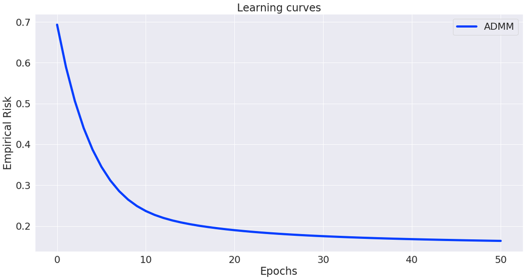

```python
clf_admm = LogisticRegression(solver='admm', l1 = 0.01, l2=0.01, max_iter=50, l1_reg = False, rho = 1)
clf_admm.fit(A_train, b_train)

learning_curve(ADMM=clf_admm)
```

# Comparison with GD and SVRG

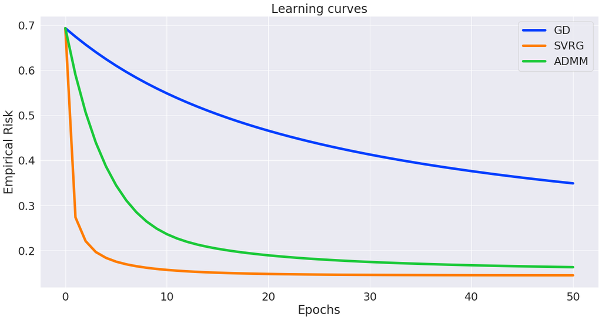

```
gd:	Accuracy on training set: 92.2%
	Accuracy on testing set:  80.8%
svrg:	Accuracy on training set: 97.0%
	Accuracy on testing set:  80.8%
admm:	Accuracy on training set: 96.3%
	Accuracy on testing set:  80.8%
```

```python
learning_curve(GD=clf_gd, SVRG=clf_svrg, ADMM=clf_admm)

for clf, name in zip([clf_gd,  clf_svrg,   clf_admm], ['gd', 'svrg', 'admm']):
    print(name + ':' \
          + "\tAccuracy on training set: {0:0.1f}%".format(100*clf.score(A_train, b_train)))
    print("\tAccuracy on testing set:  {0:0.1f}%".format(100*clf.score(A_test, b_test)))
```

# Adding lasso regularization

Minimization of the empirical risk $f$ of both $L_1$ and $L_2$-regularized logistic regression model: $$ \textrm{min}_{x\in \mathbb{R}^d} \ \frac{1}{n_{\textrm{train}}} \sum_{i=1}^{n_{\textrm{train}}} f_i(x), $$ where $f_i(x) = LogisticLoss(b_i, <a_i, x>) + l_1 \| x \|_1 + \frac{l_2}{2}\|x\|^2_2 = g_i(x) + l_1 \| x \|_1$

Task: $$ \begin{cases} \textrm{minimize} & \frac{1}{n_{\textrm{train}}} \sum_{i=1}^{n_{\textrm{train}}} g_i(x_i) + l_1 \| z \|_1, \\ \textrm{subject to} & \forall i, x_i = z. \end{cases} $$

Augmented Lagrangian: $$ L_{\rho}(x_i,z,y_i) = \frac{1}{n_{\textrm{train}}} \sum_{i=1}^{n_{\textrm{train}}} \left( g_i(x_i) + l_1 \| z \|_1+ y_i^T (x_i - z) + \frac{\rho}{2} \|x_i - z\|^2_2\right) = \frac{1}{n_{\textrm{train}}} \sum_{i=1}^{n_{\textrm{train}}} L_{\rho}(x_i,z,y_i)_i $$ ADMM: $$ x_i^{k+1} = \text{argmin}_{x_i} L_{\rho}(x_i,z^k,y_i^k)_i = \text{argmin}_{x_i} g_i(x_i) + y_i^T (x_i - z) + \frac{\rho}{2} \|x_i - z\|^2_2 \ \text{ \\\ x-minimization} $$ $$ z^{k+1} = \text{argmin}_{z} L_{\rho}(x_i^{k+1},z,y_i^k) = \text{prox}_{\frac{l_1}{\rho} \|.\|_1}\left(\frac{1}{n_{\textrm{train}}} \sum_{i=1}^{n_{\textrm{train}}} x_i^{k+1} + \frac{1}{\rho} y_i^k \right)\ \text{ \\\ z-minimization} $$ $$ y_i^{k+1} = y_i^{k} + \nabla_{y_i} L_{\rho}(x_i^{k+1},z^{k+1},y_i)_i = y_i^k + \rho (x_i^{k+1} - z^{k+1}) \ \text{ \\\ dual update} $$

# Comparison with GD and SVRG

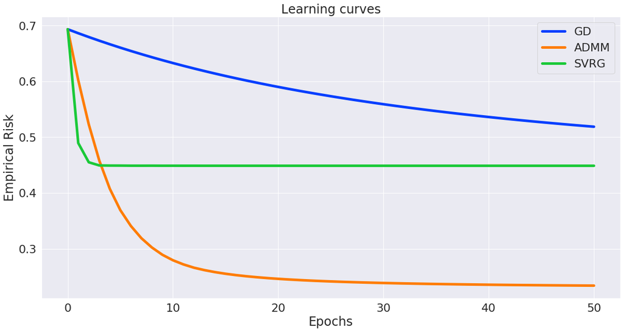

```
gd:	Accuracy on training set: 90.9%
	Accuracy on testing set:  82.8%
admm:	Accuracy on training set: 95.3%
	Accuracy on testing set:  86.9%
svrg:	Accuracy on training set: 91.2%
	Accuracy on testing set:  83.8%
```

```python
epochs = 50
n = len(b_train)

clf_gd = LogisticRegression(solver='gd', l1 = 0.01, l2=0.01, max_iter=epochs, l1_reg = True,)
clf_svrg = LogisticRegression(solver='svrg', l1 = 0.01, l2=0.01, max_iter=epochs, l1_reg = True,)
clf_admm = LogisticRegression(solver='admm', l1 = 0.01, l2=0.01, max_iter=epochs, l1_reg = True, rho = 1)


clf_gd.fit(A_train, b_train)
clf_svrg.fit(A_train, b_train)
clf_admm.fit(A_train, b_train)


learning_curve(GD=clf_gd, ADMM=clf_admm, SVRG=clf_svrg)

for clf, name in zip([clf_gd,   clf_admm,  clf_svrg], ['gd', 'admm', 'svrg']):
    print(name + ':' \
          + "\tAccuracy on training set: {0:0.1f}%".format(100*clf.score(A_train, b_train)))
    print("\tAccuracy on testing set:  {0:0.1f}%".format(100*clf.score(A_test, b_test)))
```

# Sparsity of the solution depending on the l1 value

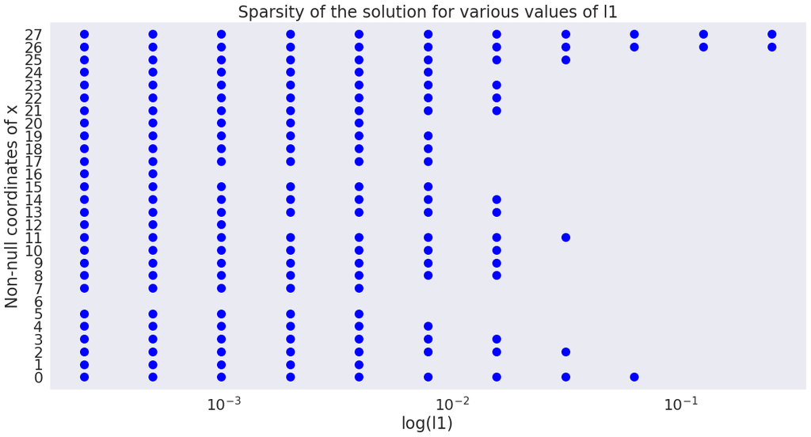

```python
clf = lambda l1: LogisticRegression(solver='admm', l1=l1, l2=0.1, max_iter=100, l1_reg = True)

l1_regularization_plot(clf, A_train, b_train)
```

# Standard or stochastic Newton method

We can compare ADMM with two Newton's methods that use non-constant stepsize depending on the hessian of function. Standard Newton method has the following update rule unlike the standard GD: $$ x^{k+1} = x^{k} - (\nabla^2 f(x^k))^{-1} \nabla f(x^k) $$ The stochastic Newton method has completely different structure of iteration:

$\\ \textbf{Step 1}. x^{k+1} = (\frac{1}{n} \sum_i \nabla^2 f_i(x^i_k))^{-1}(\frac{1}{n} \sum_i \nabla^2 f_i(x^i_k) x^i_k - \nabla f_i(x^i_k))$

$\\ \textbf{Step 2}. \text{Sample } S_k \subseteq \{1,2,..,n\}$

$\\ \textbf{Step 3}. x_{k+1}^i = \begin{cases} x^{k+1} & \text{ if } i \in S_k, \\ x^i_k & \text{ if } i \notin S_k \end{cases}$

where $x^1_0, x^2_0, .. , x^n_0$ are different otherwise it will be the standard NM.

# Comparison of ADMM, SVRG as the best one among proposed algo-s, standard(NM) and stochastic(SNM) Newton's methods

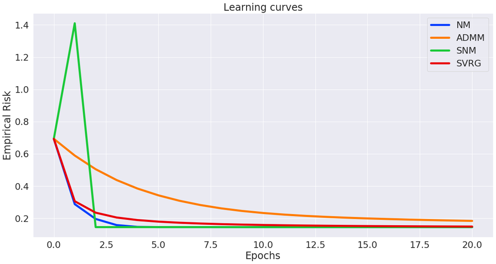

```
nm:	Accuracy on training set: 97.0%
	Accuracy on testing set:  80.8%
admm:	Accuracy on training set: 95.9%
	Accuracy on testing set:  79.8%
snm:	Accuracy on training set: 97.0%
	Accuracy on testing set:  80.8%
svrg:	Accuracy on training set: 97.0%
	Accuracy on testing set:  80.8%
```

```python
epochs = 20
n = len(b_train)

clf_gd = LogisticRegression(solver='gd', l2=0.01, max_iter=epochs, newton = True)
clf_sgd = LogisticRegression(solver='sgd',  l2=0.01, max_iter=epochs*n, newton = True)
clf_admm = LogisticRegression(solver='admm', l2=0.01, max_iter=epochs, rho = 1, newton= True)
clf_svrg = LogisticRegression(solver='svrg', l2=0.01, max_iter=epochs,  newton= True)


clf_gd.fit(A_train, b_train)
clf_sgd.fit(A_train, b_train)
clf_admm.fit(A_train, b_train)
clf_svrg.fit(A_train, b_train)


learning_curve(NM=clf_gd, ADMM=clf_admm, SNM=clf_sgd, SVRG = clf_svrg)

for clf, name in zip([clf_gd,   clf_admm,  clf_sgd, clf_svrg], ['nm', 'admm', 'snm', 'svrg']):
    print(name + ':' \
          + "\tAccuracy on training set: {0:0.1f}%".format(100*clf.score(A_train, b_train)))
    print("\tAccuracy on testing set:  {0:0.1f}%".format(100*clf.score(A_test, b_test)))
```

# Conclusion

We compared the four proposed algorithms. With selected step size values, stochastic algorithms favorably differ from ordinary gradient descent, but at the same time they have approximately the same convergence between themselves.

ADMM was also introduced, which was compared with the standard gradient descent and the best stochastic, SVRG. ADMM showed a median result for l2-regularization and excellent for the case of l1- and l2-regularizations, while we got a sparse solution, that is, the goal of l1-regularization was achieved.